STAT5003 Presentation

Machine Learning Approaches for Tree Species Classification from Sentinel-2 Data in Germany

Mingyuan Zhong, Boxin Wang, Ting Hou, Lingyu Kang, Zhengping Wang

W11_G04

[figure not shown]

Research Question & Why we do this

RQ:

How can we determine the specific species of tree samples at a particular observation point using Sentinel-2 remote sensing multi-time series data?

Why it is matters:

· Scientifically manage forests and reduce risks

· Serving the forestry industry and ecological economy

· Australian ecological conservation

Dataset

Data Source

· From the Earth System Science Data (ESSD) journal article: “A Sentinel-2 Machine Learning Dataset for Tree Species Classification in Germany”

· Based on the German National Forest Inventory (NFI, 2012), the most comprehensive forest survey.

· The remote sensing imagery is from the Sentinel-2 satellite and processed to produce a ready-to-use reflectance time series.

Key Description

· The data is provided as a SQLite database file.

· Each observation record contains the multi-band reflectance and related information for a single tree at a specific point in time.

Dataset con’t

Data Overview

· 89,137,784 observations(Approximately 387,775 trees)

· 18 variables, 52 categories

Data Challenges

· Large Size: Large data size.

· Messy Data: Missing values.

· Integration: Requires integration of multiple data sources (NFI + Sentinel-2).

· Multi-class Imbalance: Multiple classes with uneven distribution.

Data Inspection

Data Observation

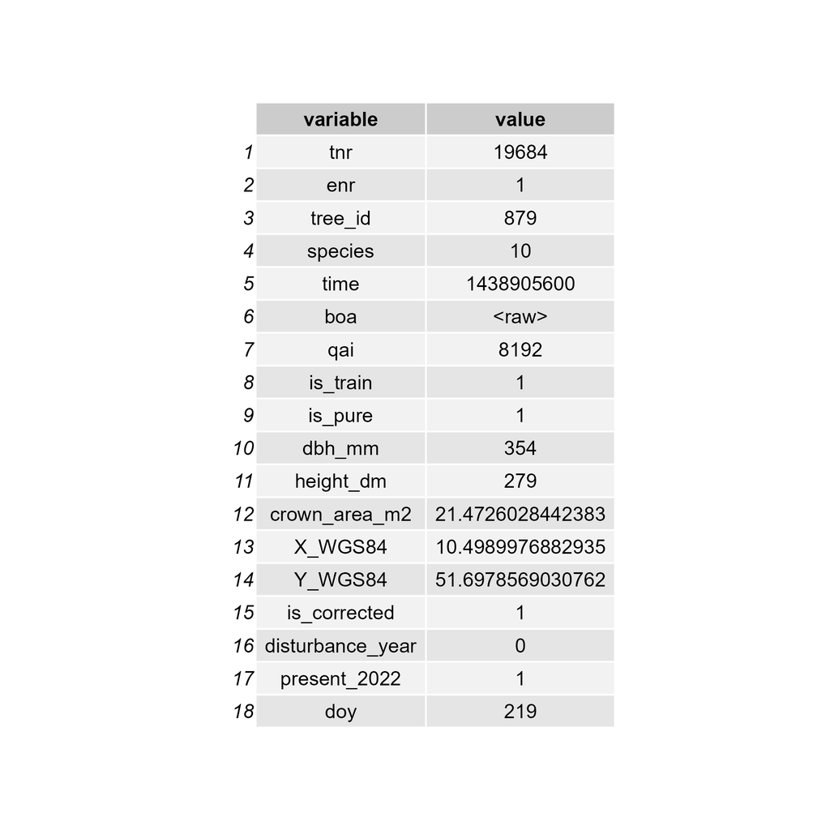

Data Inspection con’t

Data categories

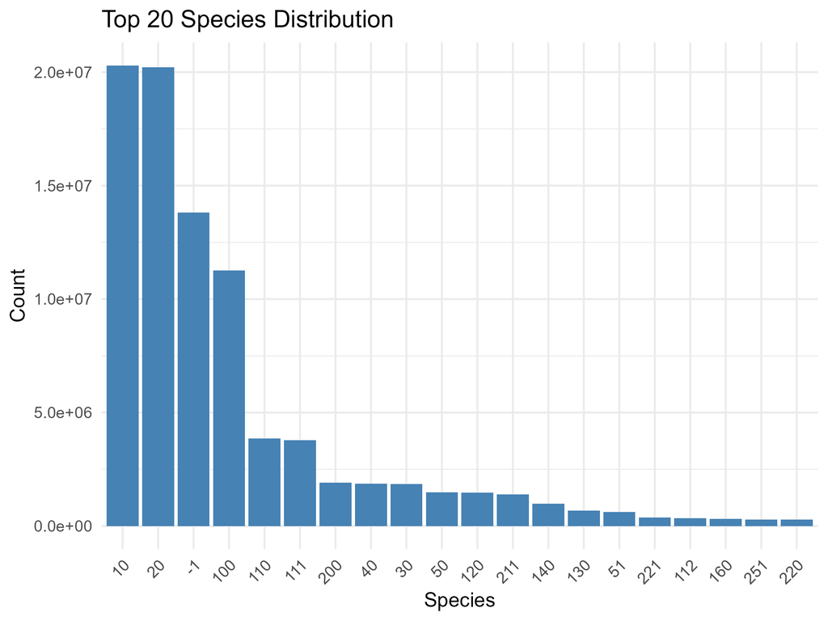

Data processing

QAI filtering

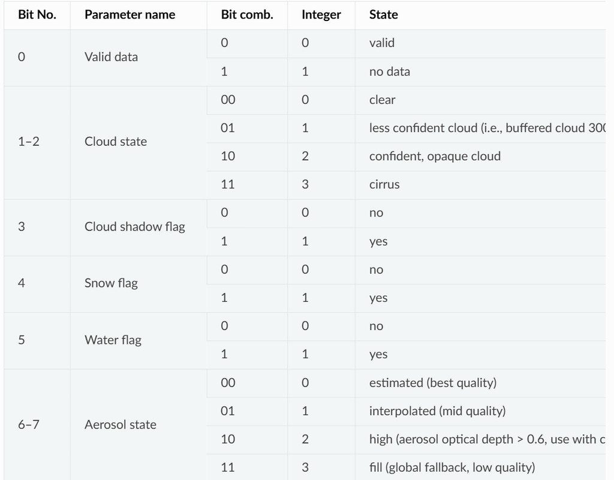

Example: 6144(0001 1000 0000 0000), 0(0000 0000 0000 0000)

After filtering: Discard 17.52% data

Data processing con’t

Data Extraction

More than 70 million observations are still very large, so we need to extract data from this dataset.

· Training set: 200 trees per class, 50 observations -> 10,000 rows per class -> 50,000 rows in total

Why this sampling strategy?

· Compressing the data to a size suitable for RStudio training.

· Evenly sampling time series for each tree, covering the four seasons

· Ensuring the time series features required for the research task

Data processing con’t

Formatting

· Binary blob Boa ->Split it into 10 values for experimental purposes.

· Time is a UNIX timestamp -> human-readable date format

Fixing errors

· The authors claim to have performed very rigorous data checks, but we still checked the training data to look for any issues beyond their definition.

EDA - What does our data Look Like

Check Null Value

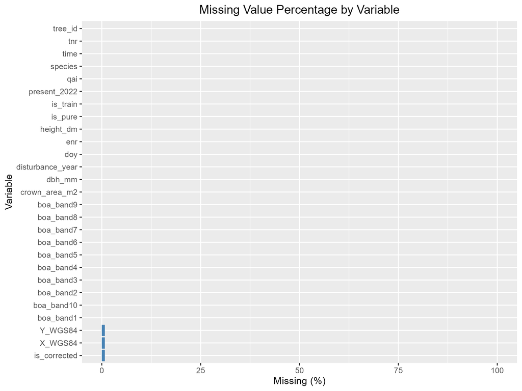

Delete directly, 50000 -> 49600.

EDA - What does our data Look Like

Outliers

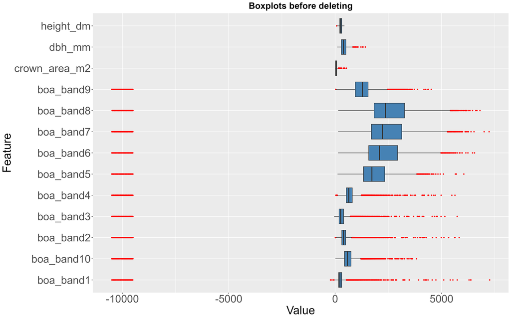

Delete boa_bond value <0 or > 10000.

49600 rows -> 49341 rows

EDA - What does our data Look Like

Key feature checking: BOA

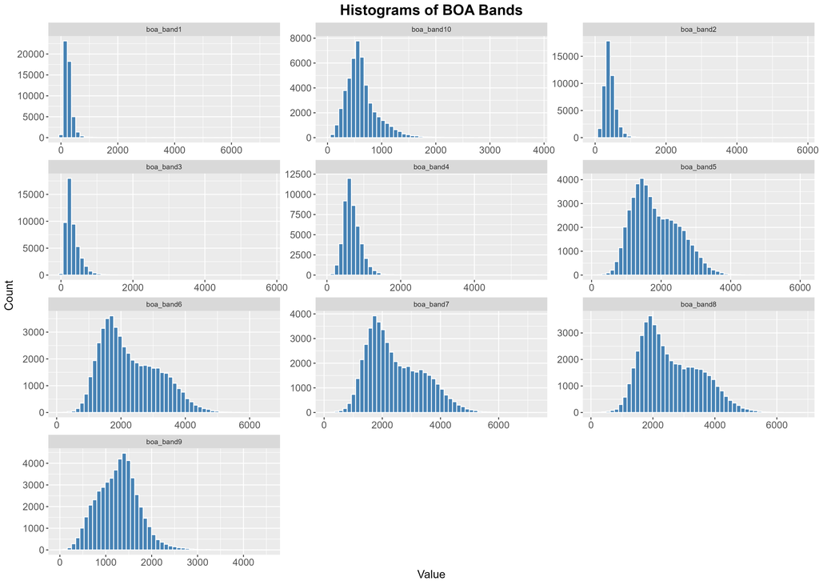

Feature Engineering Before Modeling

Feature Choices: 10 numbers of BOA

· 10 BOA bands = the “color response” of leaves under different light conditions..

· Different tree species exhibit unique “textures” in these bands.

· Combining these features allows for the differentiation of different tree species, such as evergreen conifers and deciduous broadleaf trees.

Feature Construction: doy_sin and doy_cos

· Make the date variable a recurring feature.

· Help the model understand the differences between spring, summer, autumn, and winter.

Feature Engineering Before Modeling con’t

Feature Construction: NDVI / EVI

· Reflects the photosynthetic activity of leaves (leaf color), increasing rapidly in spring and declining significantly in autumn.

· NDVI = (NIR − Red) / (NIR + Red).

· EVI = 2.5 × (NIR − Red) / (NIR + 6 × Red − 7.5 × Blue + 1).

Feature Construction: NDRE

· Reflects leaf structure and thickness.

· NDRE = (NIR − RedEdge) / (NIR + RedEdge).

Feature Construction: NDWI

· Measures leaf water content.

· NDWI = (NIR − SWIR) / (NIR + SWIR).

Note:boa_band7 = NIR, boa_band3 = Red, boa_band1 = Blue, boa_band4 = Red Edge, boa_band9 = SWIR1

Categories Distribution

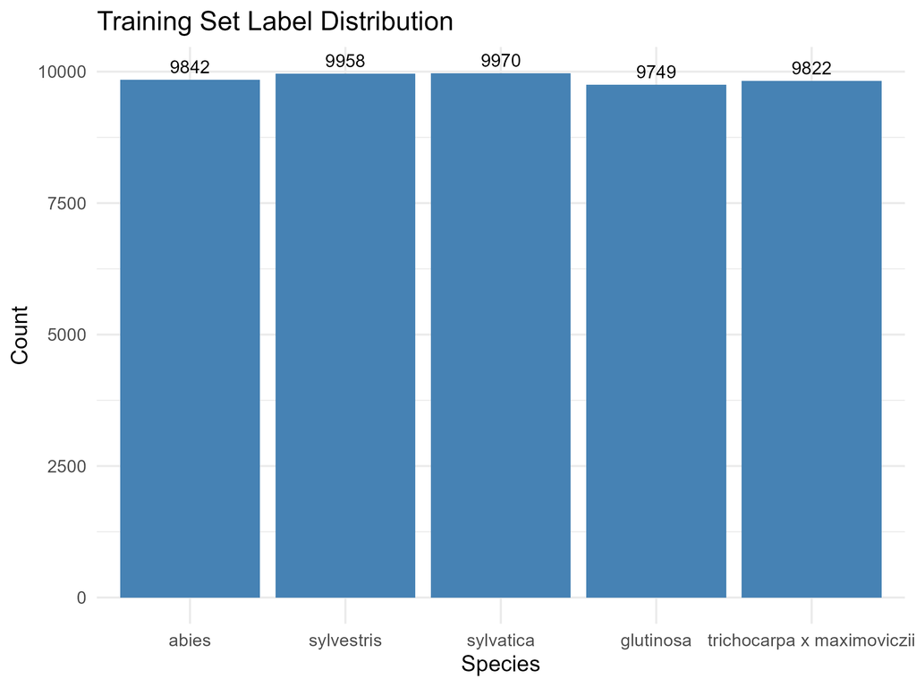

Modeling

Using grid search + 5 fold CV

Logistic regression

· Best Hyperparameters: (alpha: 0.5, lambda: 0.00058573)

Decision Tree

· Best Hyperparameters: (cp:1e-04,minsplit:2,maxdepth:22)

Random Forest

· Best Hyperparameters: (mtry:12, min.node.size:5, ntree:500)

Adaboost

· Best Hyperparameters: (mfinal = 300，maxdepth = 4，minsplit = 100)

Xgboost

· Best Hyperparameters: (max_depth = 8, eta = 0.10, subsample = 0.8, colsample_bytree = 0.8, min_child_weight = 1)

Model Evaluation

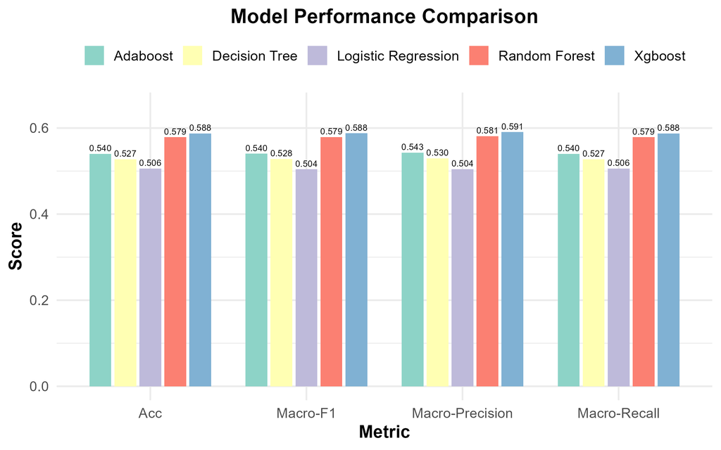

Final insights

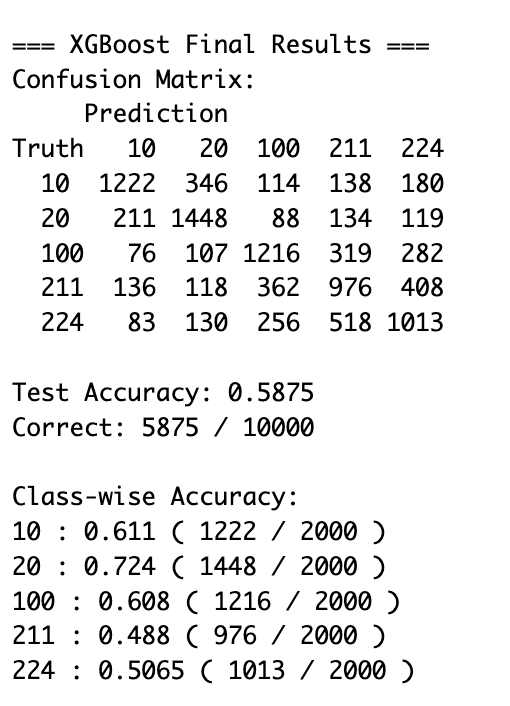

Final insights

Why the accuracy is not high

· Natural prior knowledge: Spectral differences between tree species are not always obvious, especially among trees of the same family/genus.

· Abies (10) vs Sylvestris (20) → Both are evergreen needles.

· sylvatica (100) vs glutinosa (211) → both are deciduous broadleaf trees.

· trichocarpa x maximoviczii (224) → hybrid poplar.

What’s Next

· Limitations of Conventional ML.

· More Appropriate Directions:Sequential Models(LSTM/RNN), Deep Learning(CNN/ResNet), Multimodal: Integrate more than just remote sensing imagery.

Thank you!

Any Question?

[figure not shown]